# Chapter 7: Evidence synthesis in a decision modelling framework.

Bob

2025-02-25

```r
library('rjags')      # coda.samples
library('dplyr')
library('tidyr')
library('jagsUI')
library('mcmcplots')  # caterplot
library('coda')
```

# `caesarean_section_example.odc`

The code below fixes a problem with the original initial values from WinBUGS not working in JAGS. The first set of initial parameter values results in this error:

```
Error in `rjags::jags.model()`:
! Error in node ce.ratio
Invalid parent values
```

unless you change the values of `p1` and `beta` to 1e-6 instead of 0.

```r
# Model

model_code <- "model
{

  # META-ANALYSIS ADJUSTING FOR BASELINE RISK

  for (i in 1:Num)
  {
    rc[i] ~ dbin(pc[i], nc[i])
    rt[i] ~ dbin(pt[i], nt[i])
    logit(pc[i]) <- mu[i]
    logit(pt[i]) <- mu[i] + delta[i]
    delta[i] <- delta.star[i] + beta * (mu[i]-(-1.09))
    mu[i] ~ dnorm(0.0,1.0E-3)
    delta.star[i] ~ dnorm(d, prec)
  }

  d ~ dnorm(0.0,1.0E-6)
  OR <- exp(d)
  d.pred ~ dnorm(d,prec)
  beta ~ dnorm(0.0,1.0E-6)

  tau ~ dunif(0,10)
  tau.sq <- tau*tau
  prec <- 1/tau.sq

  # DEVIANCE CONTRIBUTION

  for (i in 1:Num)
  {
    rthat[i] <- pt[i] * nt[i]
    dev[i] <- 2 * (rt[i] * (log(rt[i])-log(rthat[i]))  +  (nt[i]-rt[i]) * (log(nt[i]-rt[i]) - log(nt[i]-rthat[i])))
  }

  sumdev <- sum(dev[])

  # DATA FOR DECISION MODEL

  # Probability of wound infection without antibiotics
  rc1 ~ dbin(p1,nc1)
  p1 ~ dbeta(1,1)

  # Probability of wound infection with antibiotics
  logit(p2) <- logit(p1) + d + beta*(logit(p1)-(-1.09))
  # Length of stay in hospital with wound infection
  loswd ~ dnorm(mnloswd,precwd)
  precwd <- 1/pow(sdloswd/sqrt(numwd),2)
  # Length of stay in hospital without wound infection
  losnwd ~ dnorm(mnlosnwd,precnwd)
  precnwd <- 1/pow(sdlosnwd/sqrt(numnwd),2)

  # Antibiotics administration costs
  drugadmin ~ dunif(4,10)

  # QALYs - wound infection
  QALYs.wd <- ((QALYwd/365)*loswd)+((Fullhealth/365)*(fllwupdays-loswd))
  # QALYs - no wound infection
  QALYs.nwd <- ((QALYnwd/365)*losnwd)+((Fullhealth/365)*(fllwupdays-losnwd))


  # DECISION MODEL

  # Cost with prophylactic antibiotics
  cst.trt <- (1-p2) * ((antibiotic+drugadmin) * 3 + (losnwd*inptnwd)) + p2 * ((antibiotic+drugadmin) * 3 + (loswd * inptwd))
  # Cost without prophylactic antibiotics
  cst.ctl <- (1-p1) * (losnwd*inptnwd) + p1 * (loswd*inptwd)
  # Difference in cost
  diff.cost <- cst.trt - cst.ctl

  # Number of wound infections avoided using prophylactic antibiotics
  diff.wd <- (nc1 * (p1 - p2))

  # QALYs - with prophylactic antibiotics
  QALYs.trt <- (1-p2) * QALYs.nwd+p2 * QALYs.wd
  # QALYs - without prophylactic antibiotics
  QALYs.ctl <- (1-p1) * QALYs.nwd+p1 * QALYs.wd
  # Difference in QALYs
  diff.QALYs <- (QALYs.trt - QALYs.ctl)

  # Probability using prophylactic antibiotics costs less than not using prophylactic antibiotics
  Q <- step(cst.ctl - cst.trt)

  # Cost effectiveness ratio
  ce.ratio <- diff.cost/diff.wd
  cu.ratio <- diff.cost/diff.QALYs

  # INCREMENTAL NET BENEFIT

  for (k in 1:M)
  {
    Rc1[k] <- (k-1) * 2000
    INB.QALYs[k] <- Rc1[k] * diff.QALYs - diff.cost
    ProbCU[k] <- step(INB.QALYs[k])
  }
}
" %>% textConnection

# Data

data <- list(
  Num=35,
  rc1=41,
  nc1=486,
  inptwd=163.03,
  inptnwd=107.26,
  mnloswd=8.8,
  sdloswd=3.5,
  mnlosnwd=6.7,
  sdlosnwd=7.1,
  numwd=41,
  numnwd=445,
  antibiotic=5.67,
  M=21,
  QALYwd=0.68,
  QALYnwd=0.88,
  Fullhealth=1,
  fllwupdays=20
)

data_df <- "rt  nt  rc  nc
4   133 28  136
2   68  1   56
5   55  8   55
3   100 0   33
4   183 3   44
0   46  4   55
0   119 1   39
2   60  6   30
1   46  1   49
0   50  2   50
1   43  1   47
0   80  3   80
2   196 14  190
2   124 2   58
2   74  8   78
4   167 5   140
0   48  2   49
0   102 1   99
0   85  3   43
6   136 16  130
0   74  2   74
2   61  2   61
3   146 9   132
1   64  7   65
0   16  1   16
2   31  6   37
1   50  2   49
2   26  0   27
3   133 12  66
6   244 17  117
1   52  2   61
2   43  4   50
2   48  3   45
3   40  1   40
1   50  4   50" %>% read.delim(text=., sep='\t')

for (colname in names(data_df)){
  data[[colname]] <- data_df[[colname]]
}

# Starting/initial values

initial_values <- list(
  list(
    tau=1,
    delta.star=c(0,0,0,0,0,0,0,0,0,0,  0,0,0,0,0,0,0,0,0,0, 0,0,0,0,0,0,0,0,0,0,  0,0,0,0,0),
    d=0,
    mu=c(0,0,0,0,0,0,0,0,0,0,  0,0,0,0,0,0,0,0,0,0, 0,0,0,0,0,0,0,0,0,0,  0,0,0,0,0),
    p1=1e-6, # 1e-6 works, 0.0 does not
    beta=1e-6  # 1e-6 works, 0.0 does not
  ),

  list(
    tau=0.1,
    delta.star=c(1,1,1,1,1,1,1,1,1,1, 1,1,1,1,1,1,1,1,1,1, 1,1,1,1,1,1,1,1,1,1, 1,1,1,1,1),
    d=1,
    mu = c(1,1,1,1,1,1,1,1,1,1, 1,1,1,1,1,1,1,1,1,1, 1,1,1,1,1,1,1,1,1,1, 1,1,1,1,1),
    p1=0.5,
    beta=1)
)

parameters_to_save <- c("ProbCU", "INB.QALYs", "Rc1", "diff.QALYs","diff.cost","OR",
                        "beta","ce.ratio","cu.ratio","p1","p2",
                        "sumdev","tau.sq")

# meta-analysis decision model
mad_results <- jags(data = data,
            inits = initial_values,
            parameters.to.save = parameters_to_save,
            model.file = model_code,
            n.chains = length(initial_values),
            n.adapt = 100,
            n.iter = 50000,
            n.burnin = 20000,
            n.thin = 2)
```

```
##
## Processing function input.......
##
## Done.
##
##
##
## Adaptive phase, 100 iterations x 2 chains
## If no progress bar appears JAGS has decided not to adapt
##
##
##  Burn-in phase, 20000 iterations x 2 chains
##
##
## Sampling from joint posterior, 30000 iterations x 2 chains
##
##
## Calculating statistics.......
##
## Done.
```

```r
mad_results_summary <- summary(mad_results) %>% as.data.frame()

mad_results_summary
```

```
##                        mean           sd          2.5%           25%
## ProbCU[1]      7.578000e-01 4.284218e-01  0.000000e+00  1.000000e+00
## ProbCU[2]      7.740000e-01 4.182461e-01  0.000000e+00  1.000000e+00
## ProbCU[3]      7.894667e-01 4.076942e-01  0.000000e+00  1.000000e+00
## ProbCU[4]      8.047667e-01 3.963868e-01  0.000000e+00  1.000000e+00
## ProbCU[5]      8.183000e-01 3.856035e-01  0.000000e+00  1.000000e+00
## ProbCU[6]      8.308667e-01 3.748759e-01  0.000000e+00  1.000000e+00
## ProbCU[7]      8.445667e-01 3.623233e-01  0.000000e+00  1.000000e+00
## ProbCU[8]      8.557667e-01 3.513320e-01  0.000000e+00  1.000000e+00
## ProbCU[9]      8.665000e-01 3.401200e-01  0.000000e+00  1.000000e+00
## ProbCU[10]     8.760333e-01 3.295490e-01  0.000000e+00  1.000000e+00
## ProbCU[11]     8.853333e-01 3.186246e-01  0.000000e+00  1.000000e+00
## ProbCU[12]     8.943333e-01 3.074156e-01  0.000000e+00  1.000000e+00
## ProbCU[13]     9.025333e-01 2.965971e-01  0.000000e+00  1.000000e+00
## ProbCU[14]     9.095000e-01 2.869015e-01  0.000000e+00  1.000000e+00
## ProbCU[15]     9.165667e-01 2.765407e-01  0.000000e+00  1.000000e+00
## ProbCU[16]     9.235000e-01 2.658009e-01  0.000000e+00  1.000000e+00
## ProbCU[17]     9.293667e-01 2.562156e-01  0.000000e+00  1.000000e+00
## ProbCU[18]     9.350333e-01 2.464711e-01  0.000000e+00  1.000000e+00
## ProbCU[19]     9.399333e-01 2.376143e-01  0.000000e+00  1.000000e+00
## ProbCU[20]     9.455333e-01 2.269400e-01  0.000000e+00  1.000000e+00
## ProbCU[21]     9.501333e-01 2.176731e-01  0.000000e+00  1.000000e+00
## INB.QALYs[1]   9.075677e+00 1.250614e+01 -1.344447e+01  2.684968e-01
## INB.QALYs[2]   9.799819e+00 1.264787e+01 -1.295757e+01  8.972310e-01
## INB.QALYs[3]   1.052396e+01 1.279000e+01 -1.248446e+01  1.512453e+00
## INB.QALYs[4]   1.124810e+01 1.293251e+01 -1.202500e+01  2.140014e+00
## INB.QALYs[5]   1.197224e+01 1.307539e+01 -1.150427e+01  2.773878e+00
## INB.QALYs[6]   1.269639e+01 1.321862e+01 -1.102100e+01  3.396962e+00
## INB.QALYs[7]   1.342053e+01 1.336220e+01 -1.054881e+01  4.004192e+00
## INB.QALYs[8]   1.414467e+01 1.350612e+01 -1.006670e+01  4.626140e+00
## INB.QALYs[9]   1.486881e+01 1.365035e+01 -9.602424e+00  5.244403e+00
## INB.QALYs[10]  1.559296e+01 1.379490e+01 -9.142289e+00  5.873923e+00
## INB.QALYs[11]  1.631710e+01 1.393976e+01 -8.675036e+00  6.497594e+00
## INB.QALYs[12]  1.704124e+01 1.408490e+01 -8.189781e+00  7.111290e+00
## INB.QALYs[13]  1.776538e+01 1.423034e+01 -7.692053e+00  7.718715e+00
## INB.QALYs[14]  1.848952e+01 1.437605e+01 -7.208094e+00  8.336909e+00
## INB.QALYs[15]  1.921367e+01 1.452202e+01 -6.731839e+00  8.957437e+00
## INB.QALYs[16]  1.993781e+01 1.466826e+01 -6.261571e+00  9.593712e+00
## INB.QALYs[17]  2.066195e+01 1.481475e+01 -5.797784e+00  1.021888e+01
## INB.QALYs[18]  2.138609e+01 1.496148e+01 -5.337112e+00  1.083993e+01
```

[output cut: 170 more lines]

```
## Rc1[18]              0 1.0000000
## Rc1[19]              0 1.0000000
## Rc1[20]              0 1.0000000
## Rc1[21]              0 1.0000000
## diff.QALYs           0 1.0000000
## diff.cost            1 0.7578000
## OR                   0 1.0000000
## beta                 0 1.0000000
## ce.ratio             1 0.7578000
## cu.ratio             1 0.7578000
## p1                   0 1.0000000
## p2                   0 1.0000000
## sumdev               0 1.0000000
## tau.sq               0 1.0000000
## deviance             0 1.0000000
```

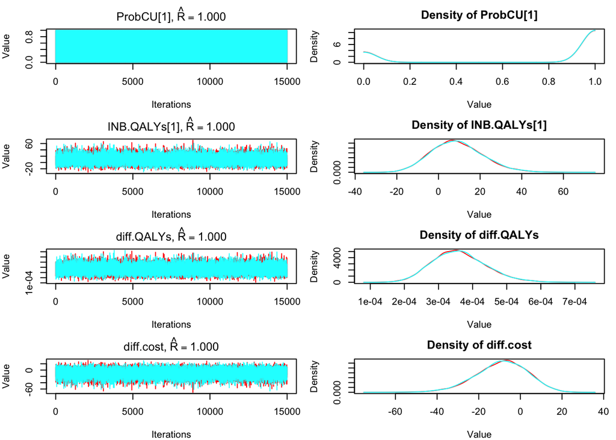

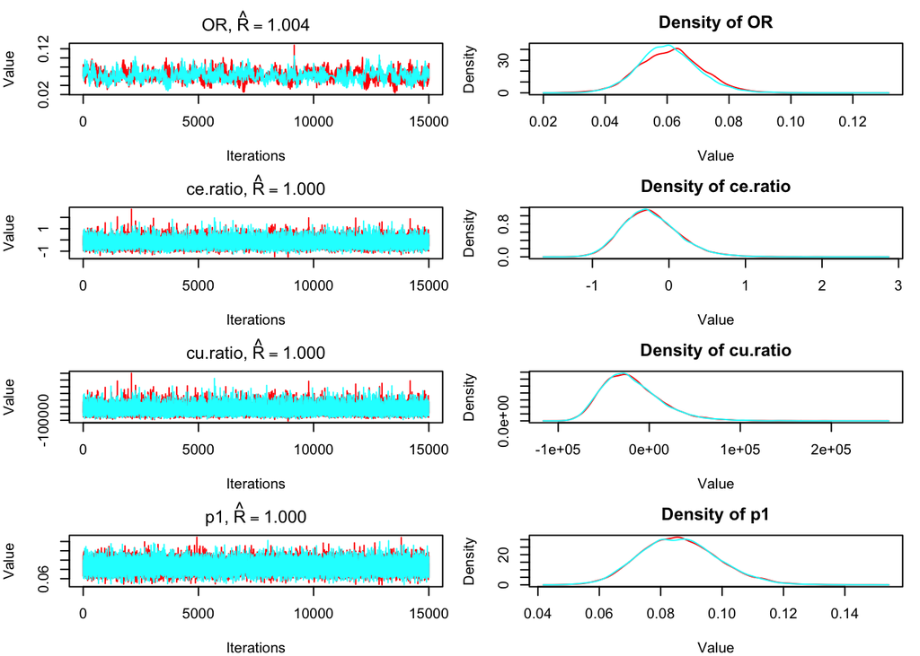

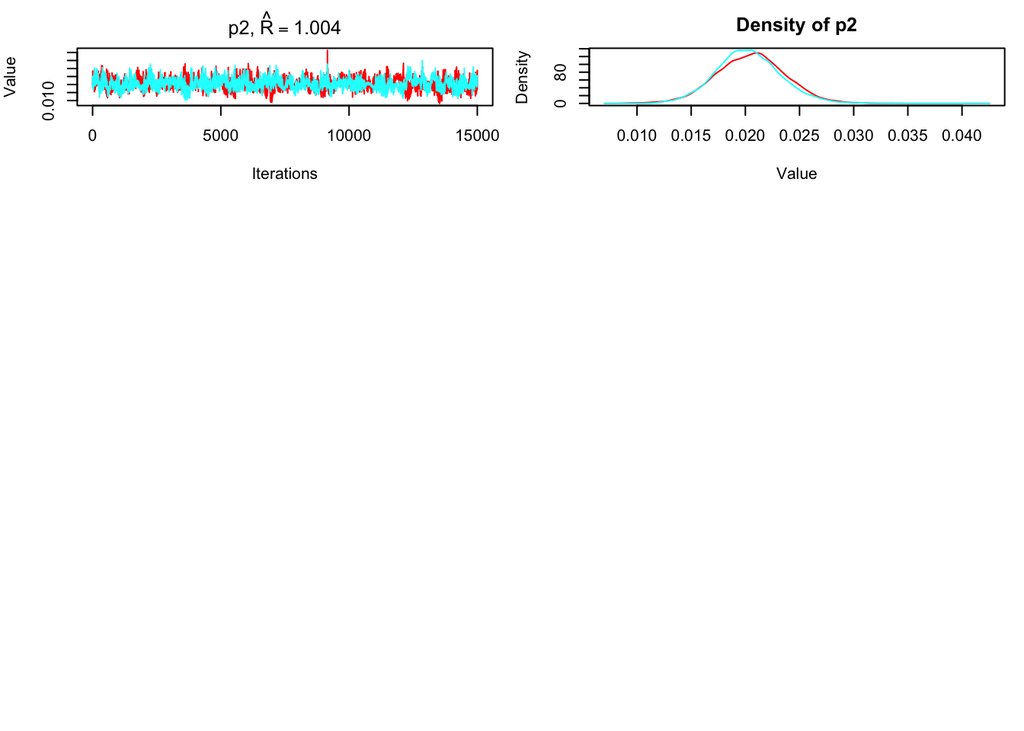

```r
plot(mad_results, parameters=c("ProbCU[1]", "INB.QALYs[1]", "diff.QALYs","diff.cost","OR",
                        "ce.ratio","cu.ratio","p1","p2") )
```

### Correlation Scatterplot (CE plane): diff.QALYs vs diff.cost

Here we re-sample the model to monitor cost-effectiveness parameters.

For an example using coda.samples, see the course notes from [Bayesian Analysis in JAGS: EMD chapter 6](https://public.wsu.edu/~jesse.brunner/classes/bio572/Lab7_Bayesian.html).

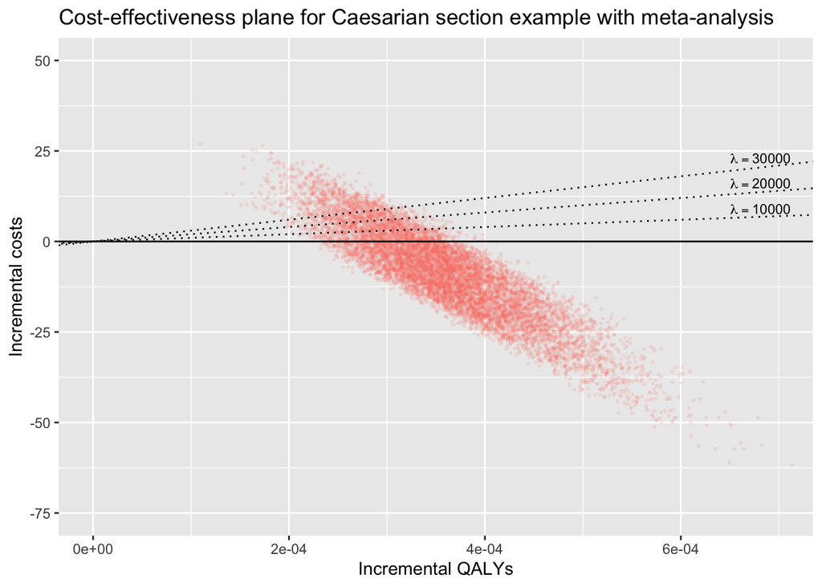

```r
ce_coda_sample <- coda.samples(mad_results$model, variable.names = c("diff.QALYs", "diff.cost"),
    n.iter = 10000)

# one set of results per chain?

library(ggplot2)
# coda_sample[[1]] %>% as.matrix %>% as.data.frame %>%
#   ggplot(aes(x=diff.QALYs, y=diff.cost)) + geom_point()

coda_sample_2_df <- function(my_coda_sample){
  seq_along(my_coda_sample) %>% lapply(function(chain){
    df <- my_coda_sample[[chain]] %>% as.matrix %>% as.data.frame
    df['chain'] <- chain
    df
  }) %>%
    bind_rows %>%
    mutate(chain=factor(chain))
}

ce_df <- ce_coda_sample %>%
  coda_sample_2_df %>%
  sample_frac(1L) # randomly scramble chain order

XLIM = c(0, 7e-4)     # use same limits as chapter 3
YLIM = c(-75, 50)
LAMBDAS = 10000*(1:3)
ce_df %>%
  filter(chain == 1) %>%  # to compare to Ch3, which had only one chain
  ggplot(aes(x=diff.QALYs, y=diff.cost, col=chain)) +
  geom_point(size=0.5, alpha=0.1) +
  geom_abline(slope=0, intercept=0, linetype='solid') +
  geom_abline(slope=LAMBDAS, intercept=0, linetype='dotted') +
  theme(legend.position="none") +
  labs(x = "Incremental QALYs", y = "Incremental costs", title="Cost-effectiveness plane for Caesarian section example with meta-analysis") +
  coord_cartesian(xlim=XLIM, ylim=YLIM) +
  annotate("text", x = XLIM[2], y = LAMBDAS * XLIM[2],
           size=3, hjust=0.8, vjust=-0.25,
           label = paste("lambda ==", LAMBDAS), parse=TRUE)
```

```r
ggsave("ce_scatterplot_ch7.png")  # compare plot to Ch.3.
```

### Cost-effectiveness

```r
# inb_vars <- c("INB", "ProbCE")
inb_vars <- c("INB.QALYs", "ProbCU")

inb_df <- coda.samples(mad_results$model, variable.names = inb_vars,
    n.iter = 10000) %>%
  coda_sample_2_df %>%
  group_by(chain) %>%
  mutate(iteration=row_number()) %>%
  ungroup() %>%
  as.data.frame

inb_df_long <- inb_df %>%
  pivot_longer(
    cols=1:42,
    names_to=c("metric", "k"),
    names_pattern="(INB.QALYs|ProbCU)\\[(\\d+)\\]",
    values_to="value"
  ) %>%
  mutate(k=as.integer(k), lambda=2000*(k-1))
```

### Cost-effectiveness acceptability curve for Caesarian section example.

Figure 3.5 [also 3.6(c)]. WTP = “Willingness To Pay”

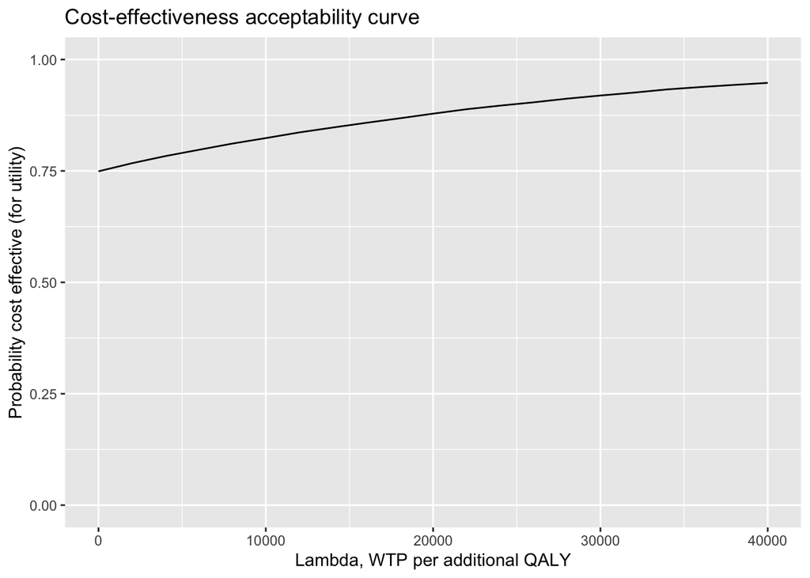

```r
inb_df_long %>%
  group_by(metric, lambda) %>%
  filter(metric=="ProbCU") %>%
  summarize(P_CU=mean(value)) %>%
  ggplot(aes(x=lambda, y=P_CU, group=metric)) + geom_line() +
    ylim(0,1) +
    ylab("Probability cost effective (for utility)") +
    xlab("Lambda, WTP per additional QALY") +
    ggtitle("Cost-effectiveness acceptability curve")
```

### Expected net benefit (INB) and 95% interval for a range of lambda values.

Figure 3.6(b): Expected incremental net benefit and 95% interval for a range of lambda.

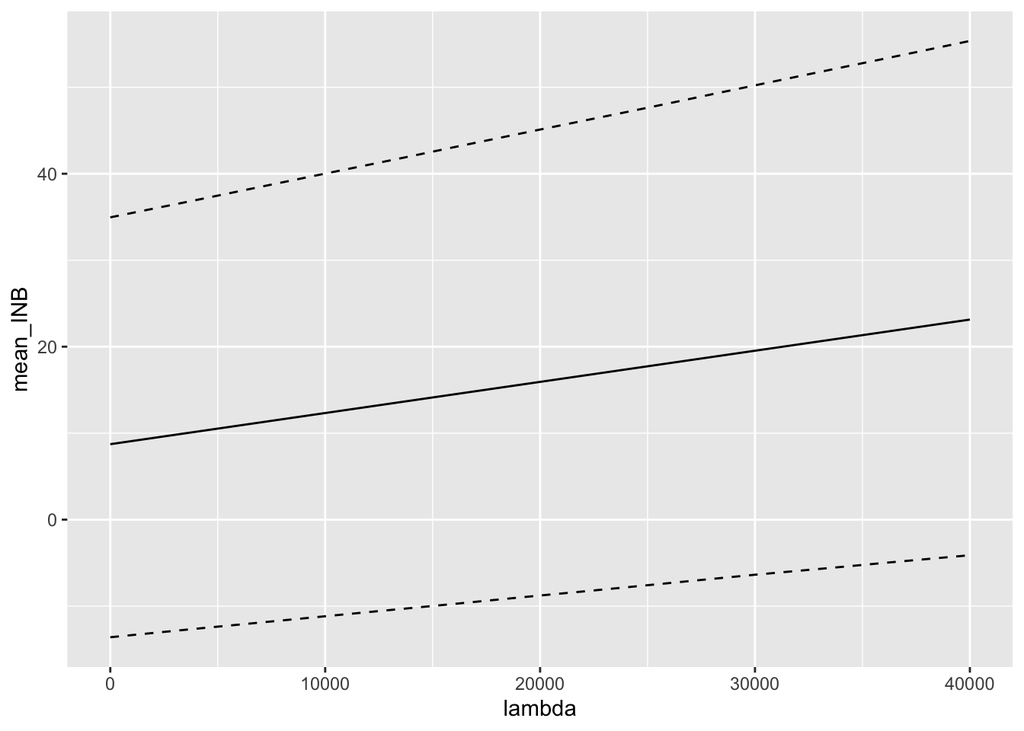

```r
 # quantile(probs = c(2.5, 50, 97.5)/100)
inb_df_long %>%
  group_by(metric, lambda) %>%
  filter(metric=="INB.QALYs") %>%
  summarize(
    mean_INB=mean(value),
    lo_end=quantile(value, probs=0.025),
    hi_end=quantile(value, probs=0.975)) %>%
  ggplot(aes(x=lambda, group=metric)) +
    geom_line(aes(y=mean_INB)) +
    geom_line(aes(y=lo_end), linetype="dashed") +
    geom_line(aes(y=hi_end), linetype="dashed")
```

# Finish these

### ScatterPlot of ProbCU vs Rc1

### Summary stats: ProbCU

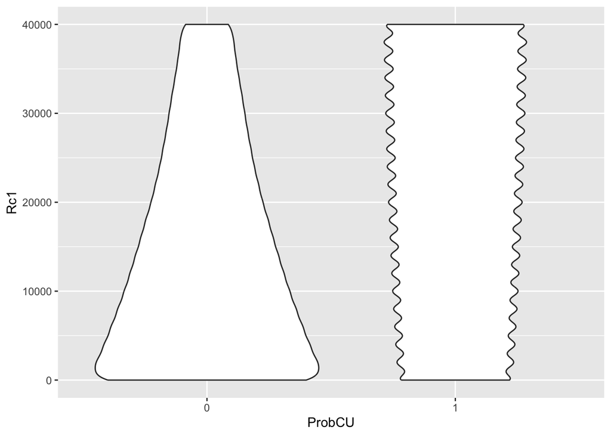

```r
# This makes 21 ProbCU columns and 21 Rc1 columns
mad_coda_df <- coda.samples(
  mad_results$model,
  variable.names = c("ProbCU", "Rc1"),
  n.iter = 10000) %>%
  coda_sample_2_df

library(tidyr)

mad_probcu_df <- mad_coda_df[,1:21] %>%
  mutate(row_num = row_number()) %>%
  pivot_longer(
    cols=names(mad_coda_df)[1:21], # ProbCU[1]:ProbCU[21],
    names_to = c("id"),
    names_pattern = "ProbCU\\[(.+)\\]",
    values_to = "ProbCU"
  )


mad_rc1_df <- mad_coda_df[,22:42] %>%
  mutate(row_num = row_number()) %>%
  pivot_longer(
    cols=names(mad_coda_df)[22:42],
    names_to = c("id"),
    names_pattern = "Rc1\\[(.+)\\]",
    values_to = "Rc1"
  )

mad_probcu_rc1_df <- merge(mad_probcu_df, mad_rc1_df)

mad_probcu_rc1_df %>%
  mutate(ProbCU=factor(ProbCU)) %>%
  ggplot(aes(x=`ProbCU`, y=`Rc1`)) + geom_violin()
```

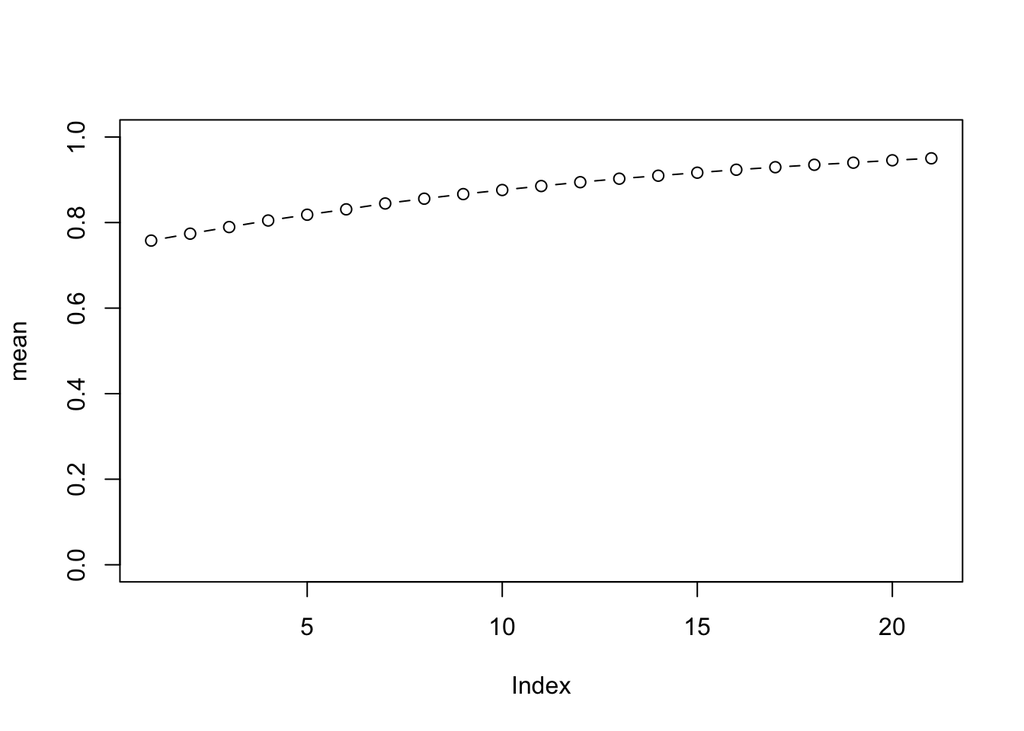

```r
ProbCU <- mad_results_summary[1:21,]
with(ProbCU, {
  plot(mean, type='b', ylim=c(0,1))
})
```

# Code for Exercises

## `Model_1_decision_model_odc.txt`

This is the code for Exercise 3.1, a deterministic decision tree comparing the use of prophylactic neuaminidase inhibitors (NIs) to standard care for influenza. Exercise 7.1a asks you to combine this with the meta-analysis in `meta-analysis.odc`.

```r
model_code <- "model
{

  # DECISION MODEL
  costtrt <- ((1-p2) *(cdoc+cdrug) +p2* (cdoc+(cdrug)+cflu))
  costctl <- ((1-p1)*(cdoc)+p1*(cdoc+cflu))
  diff.cost <- costtrt-costctl

}" %>% textConnection

#DATA

data <- list(
  cdrug=118,    # cost of neuraminidase treatment
  cdoc=19,      # cost of visit to GP
  cflu=100,     # cost of treating flu
  p1=0.05,      # probability of contracting flu under standard care
  p2=0.03       # probability of contracting flu under NI prophylaxis
)

#RESULTS

results <- jags(
  data = data,
  parameters.to.save = c("cdrug", "cdoc", "cflu", "p1", "p2",
                         "costtrt", "costctl", "diff.cost"),
  model.file = model_code,
  n.chains = 1,
  n.iter=1
)
```

```
##
## Processing function input.......
##
## Done.
##
##
##
## Adaptive phase.....
## Adaptive phase complete
##
## No burn-in specified
##
## Sampling from joint posterior, 1 iterations x 1 chains
##
```

```
##
## Calculating statistics.......
##
## Done.
```

```r
results
```

```
## JAGS output for model '5', generated by jagsUI.
## Estimates based on 1 chains of 1 iterations,
## adaptation = 100 iterations (sufficient),
## burn-in = 0 iterations and thin rate = 1,
## yielding 1 total samples from the joint posterior.
## MCMC ran for 0 minutes at time 2025-04-02 21:59:20.780938.
##
##             mean sd   2.5%    50%  97.5% overlap0 f
## cdrug     118.00 NA 118.00 118.00 118.00    FALSE 1
## cdoc       19.00 NA  19.00  19.00  19.00    FALSE 1
## cflu      100.00 NA 100.00 100.00 100.00    FALSE 1
## p1          0.05 NA   0.05   0.05   0.05    FALSE 1
## p2          0.03 NA   0.03   0.03   0.03    FALSE 1
## costtrt   140.00 NA 140.00 140.00 140.00    FALSE 1
## costctl    24.00 NA  24.00  24.00  24.00    FALSE 1
## diff.cost 116.00 NA 116.00 116.00 116.00    FALSE 1
##
## overlap0 checks if 0 falls in the parameter's 95% credible interval.
## f is the proportion of the posterior with the same sign as the mean;
## i.e., our confidence that the parameter is positive or negative.
```

## `meta_analysis_odc.txt`

This code is for the NI Meta-Analysis that goes with Exercise 7.1a.

```r
meta_analysis_model_code <- "model {

  # META-ANALYSIS OF EFFECTIVENESS - ODDS RATIO (OR)

  for( j in 1 : Num )
    {
      rc[j] ~ dbin(pc[j], nc[j])
      rt[j] ~ dbin(pt[j], nt[j])
      logit(pc[j]) <- mu[j]
      logit(pt[j]) <- mu[j]+delta[j]
      delta[j] ~ dnorm(d,prec)
      mu[j] ~ dnorm(0.0,1.0E-6)
    }

  # PRIOR DISTRIBUTIONS

  d ~ dnorm(0.0,1.0E-6)
  tau ~ dunif(0,10)
  tau.sq <- tau*tau
  prec <- 1/tau.sq

  # ODDS RATIO

  or <- exp(d)

}" %>% textConnection

# DATA
data <- list(
  rt=c(3,3,11,7,3),  nt=c(268,252,553,414,144),     # Trial data - treatment arm
  rc=c(19,6,34,40,9),  nc=c(268,251,554,423,144),   # Trial data - standard care arm
  Num = 5                                                       # number of studies in the meta-analysis
)

# INITIAL VALUES: This is a list of lists, one per chain.
initial_values <- list(
  list(tau=1, d=0, mu=c(0,0,0,0,0), delta=c(0,0,0,0,0))
)

meta_analysis_results <- jags(data = data,
            inits = initial_values,
            parameters.to.save = c("d", "tau", "or"),
            model.file = meta_analysis_model_code,
            n.chains = length(initial_values),
            n.adapt = 100,
            n.iter = 50000,
            n.burnin = 20000)
```

```
##
## Processing function input.......
##
## Done.
##
##
##
## Adaptive phase, 100 iterations x 1 chains
## If no progress bar appears JAGS has decided not to adapt
##
##
##  Burn-in phase, 20000 iterations x 1 chains
##
##
## Sampling from joint posterior, 30000 iterations x 1 chains
##
##
## Calculating statistics.......
##
## Done.
```

```r
summary(meta_analysis_results)
```

```
##                mean        sd        2.5%        25%        50%        75%
## d        -1.4455492 0.4133731 -2.24904829 -1.6545756 -1.4401122 -1.2377762
## tau       0.5291093 0.5353456  0.01560194  0.1790182  0.3823305  0.6960633
## or        0.2604388 0.2669441  0.10549958  0.1911732  0.2369012  0.2900285
## deviance 49.0639425 3.8646924 43.24043593 46.2823620 48.4642938 51.2221890
##               97.5% Rhat n.eff overlap0      f
## d        -0.6491287   NA     1        0 0.9951
## tau       2.0245626   NA     1        0 1.0000
## or        0.5225009   NA     1        0 1.0000
## deviance 58.2091863   NA     1        0 1.0000
```

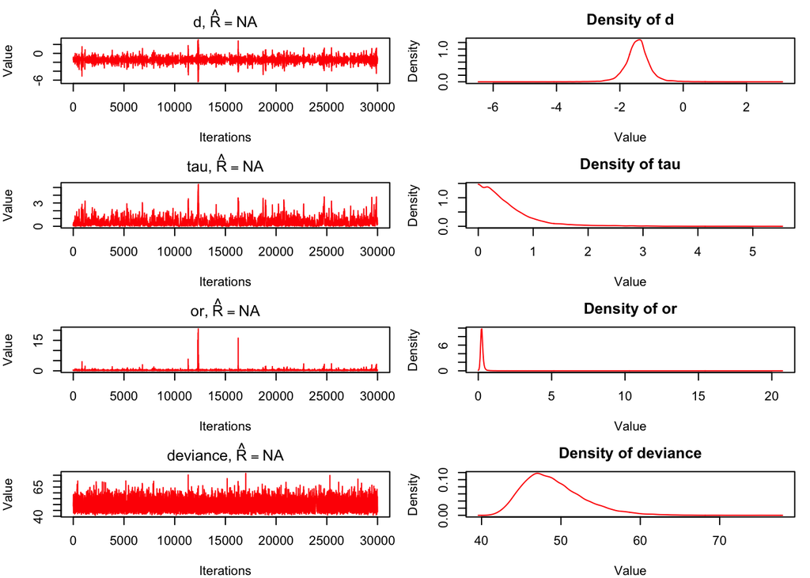

```r
plot(meta_analysis_results)
```

## `Model 3 - CEAC.xls`

Exercise 7.2c asks you to paste the values for ProbCE into the yellow shaded cells of this spreadsheet to plot a graph that includes the cost-effectiveness acceptability curve.

# TO DO: Plot the graph for exercise 7.2c in R.

# Solutions to Exercises

## Question 7.1: Decision model + Meta-Analysis solution

```r
model_code <- "
model
{

  # META-ANALYSIS OF EFFECTIVENESS - ODDS RATIO (OR)

  for (j in 1:Num)
  {
    rc[j] ~ dbin(pc[j], nc[j])
    rt[j] ~ dbin(pt[j], nt[j])
    logit(pc[j]) <- mu[j]
    logit(pt[j]) <- mu[j]+delta[j]
    delta[j] ~ dnorm(d,prec)
    mu[j] ~ dnorm(0.0,1.0E-6)
  }

  # PRIOR DISTRIBUTIONS

  d ~ dnorm(0.0,1.0E-6)
  tau ~ dunif(0,10)
  tau.sq <- tau*tau
  prec <- 1/tau.sq

  # ODDS RATIO

  or <- exp(d)


  #CALCULATION OF p2 FROM ODDS RATIO

  logit(p2) <- logit(p1)+d

  #DECISION MODEL

  costtrt <- ((1-p2) *(cdoc+cdrug) +p2* (cdoc+(cdrug)+cflu))
  costctl <- ((1-p1)*(cdoc)+p1*(cdoc+cflu))
  diff.cost <- costtrt-costctl

}" %>% textConnection

#DATA

data <- list(
  rt=c(3,3,11,7,3),  nt=c(268,252,553,414,144),   # Trial data - treatment arm
  rc=c(19,6,34,40,9),  nc=c(268,251,554,423,144), # Trial data - standard care arm
  Num = 5,              # number of studies in the meta-analysis
  cdrug=118,        # cost of neuraminidase treatment
  cdoc=19,              # cost of visit to GP
  cflu=100,             # cost of treating flu
  p1=0.05                   # prob of contracting flu under standard care
)

#INITIAL VALUES
initial_values <- list(
  list(tau=1, d=0, mu=c(0,0,0,0,0), delta=c(0,0,0,0,0))
)

parameters_to_save <- c("costtrt", "delta", "diff.cost", "mu", "or", "p2", "tau.sq")

ex1_results <- jags(data = data,
            inits = initial_values,
            parameters.to.save = parameters_to_save,
            model.file = model_code,
            n.chains = length(initial_values),
            n.adapt = 100,
            n.iter = 50000,
            n.burnin = 20000)
```

```
##
## Processing function input.......
##
## Done.
##
##
##
## Adaptive phase, 100 iterations x 1 chains
## If no progress bar appears JAGS has decided not to adapt
##
##
##  Burn-in phase, 20000 iterations x 1 chains
##
##
## Sampling from joint posterior, 30000 iterations x 1 chains
##
##
## Calculating statistics.......
##
## Done.
```

```r
ex1_summary <- summary(ex1_results) %>% as.data.frame
ex1_summary['node'] <- row.names(ex1_summary)

ex1_summary
```

```
##                   mean          sd          2.5%           25%          50%
## costtrt   138.32550324 0.936691840  1.375709e+02 137.985132238 138.21203137
## delta[1]   -1.63928997 0.428376099 -2.651666e+00  -1.862251551  -1.59243404
## delta[2]   -1.26669097 0.494144598 -2.130421e+00  -1.586357454  -1.32072534
## delta[3]   -1.33280762 0.307421031 -1.905558e+00  -1.543727817  -1.34447680
## delta[4]   -1.63770693 0.339223134 -2.388733e+00  -1.839778986  -1.60727842
## delta[5]   -1.38189535 0.452007727 -2.264181e+00  -1.652069549  -1.40600637
## diff.cost 114.32550324 0.936691840  1.135709e+02 113.985132238 114.21203137
## mu[1]      -2.65114793 0.234455160 -3.129566e+00  -2.804039513  -2.64513189
## mu[2]      -3.62536624 0.371132036 -4.426167e+00  -3.855752708  -3.60394278
## mu[3]      -2.70627305 0.168523788 -3.053523e+00  -2.816267417  -2.70073415
## mu[4]      -2.30525794 0.165225287 -2.637283e+00  -2.414462230  -2.30243069
## mu[5]      -2.70712636 0.325021181 -3.391099e+00  -2.915481429  -2.69407385
## or          0.25917860 0.540430547  1.090990e-01   0.189037394   0.23311134
## p2          0.01325503 0.009366918  5.709272e-03   0.009851322   0.01212031
## tau.sq      0.52074386 1.478765454  3.707864e-04   0.033280574   0.13999762
## deviance   49.06010984 3.882902360  4.327931e+01  46.245932527  48.43140122
##                    75%        97.5% Rhat n.eff overlap0         f      node
## costtrt   138.50029860 139.63827343   NA     1        0 1.0000000   costtrt
## delta[1]   -1.36071610  -0.91733691   NA     1        0 0.9999333  delta[1]
## delta[2]   -1.00203270  -0.14034669   NA     1        0 0.9830333  delta[2]
## delta[3]   -1.13384819  -0.70617048   NA     1        0 1.0000000  delta[3]
## delta[4]   -1.40861970  -1.04377360   NA     1        0 1.0000000  delta[4]
## delta[5]   -1.12740104  -0.40121185   NA     1        0 0.9949333  delta[5]
## diff.cost 114.50029860 115.63827343   NA     1        0 1.0000000 diff.cost
## mu[1]      -2.49125030  -2.20774649   NA     1        0 1.0000000     mu[1]
## mu[2]      -3.37013265  -2.96092644   NA     1        0 1.0000000     mu[2]
## mu[3]      -2.59210270  -2.39031235   NA     1        0 1.0000000     mu[3]
## mu[4]      -2.19340755  -1.98588965   NA     1        0 1.0000000     mu[4]
## mu[5]      -2.48201235  -2.10616860   NA     1        0 1.0000000     mu[5]
## or          0.28939858   0.51485524   NA     1        0 1.0000000        or
## p2          0.01500299   0.02638273   NA     1        0 1.0000000        p2
## tau.sq      0.44709953   3.37910071   NA     1        0 1.0000000    tau.sq
## deviance   51.20484023  58.35514614   NA     1        0 1.0000000  deviance
```

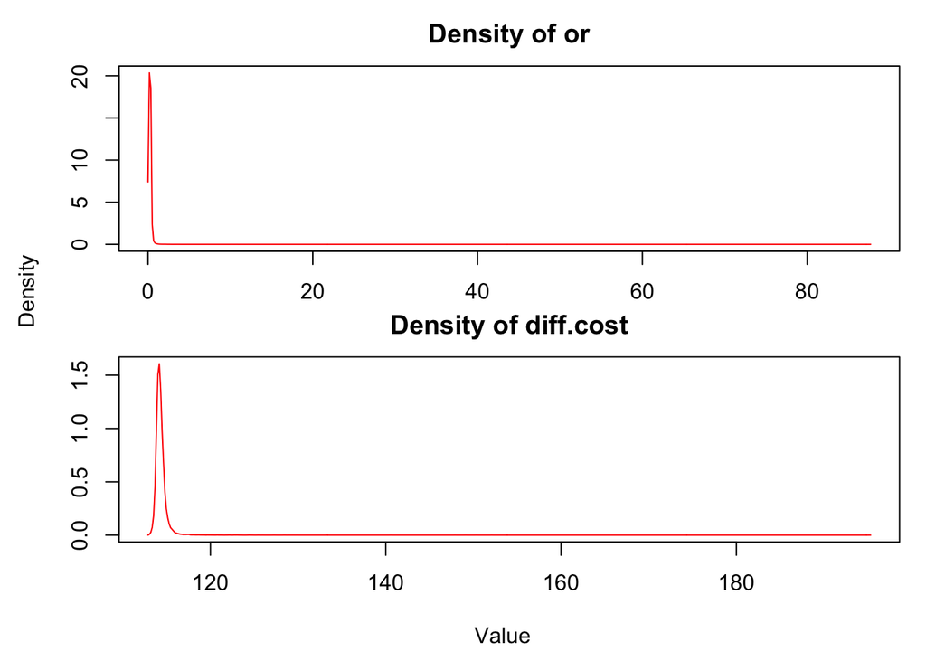

```r
densityplot(ex1_results, parameters=c('or', 'diff.cost'))
```

Comparing to the “official” answers from Solutions to Exercises, all the values plot on top of one another (except deviance, which does not appear in the official results).

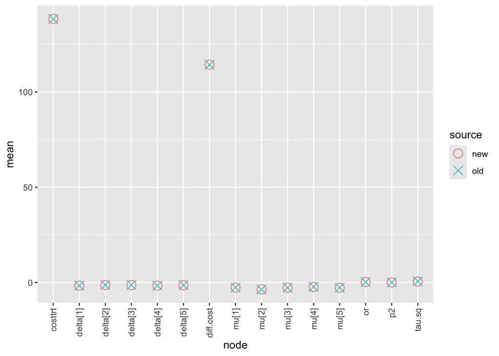

```r
official_results <- "node    mean    sd  M_error    2.5pct  median  97.5pct start   sample
costtrt 138.3   1.277   0.01573 137.5   138.2   139.6   5001    15000
delta[1]    -1.642  0.4318  0.00834 -2.655  -1.588  -0.9232 5001    15000
delta[2]    -1.268  0.4882  0.008834    -2.139  -1.315  -0.1579 5001    15000
delta[3]    -1.327  0.3072  0.006392    -1.904  -1.336  -0.6997 5001    15000
delta[4]    -1.638  0.3415  0.007694    -2.404  -1.609  -1.047  5001    15000
delta[5]    -1.384  0.4494  0.00709 -2.284  -1.395  -0.4277 5001    15000
diff.cost   114.3   1.277   0.01573 113.5   114.2   115.6   5001    15000
mu[1]   -2.649  0.2367  0.002346    -3.135  -2.641  -2.201  5001    15000
mu[2]   -3.625  0.3676  0.003682    -4.409  -3.603  -2.964  5001    15000
mu[3]   -2.709  0.1697  0.002022    -3.055  -2.705  -2.391  5001    15000
mu[4]   -2.301  0.1639  0.001936    -2.633  -2.296  -1.993  5001    15000
mu[5]   -2.709  0.3232  0.003224    -3.378  -2.692  -2.118  5001    15000
or  0.2645  0.42    0.004911    0.1042  0.2357  0.5086  5001    15000
p2  0.01346 0.01277 1.573E-4    0.005455    0.01225 0.02607 5001    15000
tau.sq  0.6589  2.799   0.05125 3.649E-4    0.1442  4.002   5001    15000" %>% read.delim(text=., sep="\t")

names(official_results) <- names(official_results) %>% gsub("X([0-9.]+)pct", "\\1%", .)

compare_cols <- c('node', 'mean', 'sd')
bind_rows(
  ex1_summary[-16, compare_cols] %>% mutate("source"='new'),
  official_results[compare_cols] %>% mutate("source"='old')
) %>% ggplot(aes(x=node, y=mean, col=source, shape=source)) +
  geom_point(size=4) +
  theme(axis.text.x = element_text(angle = 90, vjust = 0.5, hjust=1)) +
  scale_shape_manual(values=c(1, 4))
```